# Predict_413_Discussion_Week_9

Singh, Gurjeet

March 9, 2018

## 1. Introduction

For this week’s discussion, we build an neaural nets models along with Auto Arima model and ETS model for comparison. We will test the performance of each model and select the best model.

## 2. Data

For this week’s discussion, I am using the same dataset (U.S Air Carrier Traffic Statistics – Revenue Passenger Miles) from the previous discussion. The figure below shows that this data has strong seasonality within each year. Along with the seasonality, there is also an upward trend to it. We notice that every summer there’s high traffic i.e. peak times. During the months of January and February, we see a dip in the traffic. This makes sense because a lot of people are back to their normal routine after the holidays. Therefore, not many people are traveling in those months.

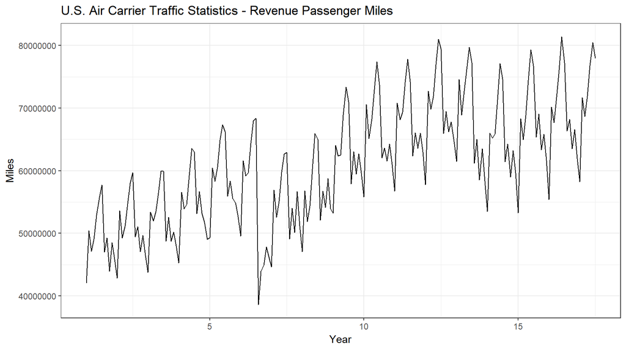

### 2.1 Split Data - Training/Test set

We split the data into the training set and test set. As per the requirement, we will hold out only 6 months of data for the test.

## 3. Model

### 3.1 Auto Models - Arima & ETS Full Data

When comparing MAE and MASE, we notice that the Auto ARIMA performed better than the other two models. When comparing RMSE, ETS model is the clear model. Since we are testing on the same data, there is a high likelihood that model is over-fitting. Hence, we would try another approach to build models with the training data (in sample data) and test the model with the test data (out of sample data).

Metrics for each model using full data

|  | ME | RMSE | MAE | MPE | MAPE | MASE | ACF1 |
| --- | --- | --- | --- | --- | --- | --- | --- |
| ARIMA(2,0,0)(0,1,1)[12] with drift | 17726.37 | 1895929 | 1139228 | -0.0876403 | 1.997818 | 0.3670247 | -0.0024269 |
| ETS(A,N,A) | 123403.47 | 1881491 | 1256336 | 0.1346370 | 2.231370 | 0.4047536 | 0.0182516 |
| NNAR(1,1,2)[12] | 98887.21 | 3184409 | 2216712 | -0.1688925 | 3.769389 | 0.7141575 | 0.4889390 |

### 3.2 Auto Model - Train & Test Data

In the result below, when comparing MAE, MAPE, and MASE for test results, we clearly see that Neural Network model performed the best. Therefore, we will select this model as our final model.

Metrics for each model

|  | ME | RMSE | MAE | MPE | MAPE | MASE | ACF1 |
| --- | --- | --- | --- | --- | --- | --- | --- |
| Auto Arima - Train | 16700.777 | 1923840 | 1161344.6 | -0.0964374 | 2.043157 | 0.3653068 | -0.0019718 |
| Auto Arima - Test | -887716.186 | 1026463 | 887716.2 | -1.1647129 | 1.164713 | 0.2792356 | 0.3591187 |
| Auto ETS - Train | 115236.101 | 1904285 | 1273352.1 | 0.1193085 | 2.269276 | 0.4005394 | 0.0192389 |
| Auto ETS - Test | 1912761.296 | 2031558 | 1912761.3 | 2.5449616 | 2.544962 | 0.6016688 | 0.3539079 |
| Auto Neural Network - Train | -1158.563 | 3194137 | 2190818.8 | -0.3496417 | 3.766630 | 0.6891332 | 0.4850520 |
| Auto Neural Network - Test | 543617.818 | 1146945 | 776930.9 | 0.7527004 | 1.066213 | 0.2443876 | -0.0106960 |

The figure below shows the forecast for each of our models. We forecasted for 12 months so we could see the trend after the test period as well. It appears that neural network model is very accurate in predicting the forecast because both the forecasted and test data overlay each other. This can be observed in the bottom graph. We also notice the similar decreasing trend for the next 6 months as we saw in the previous months.

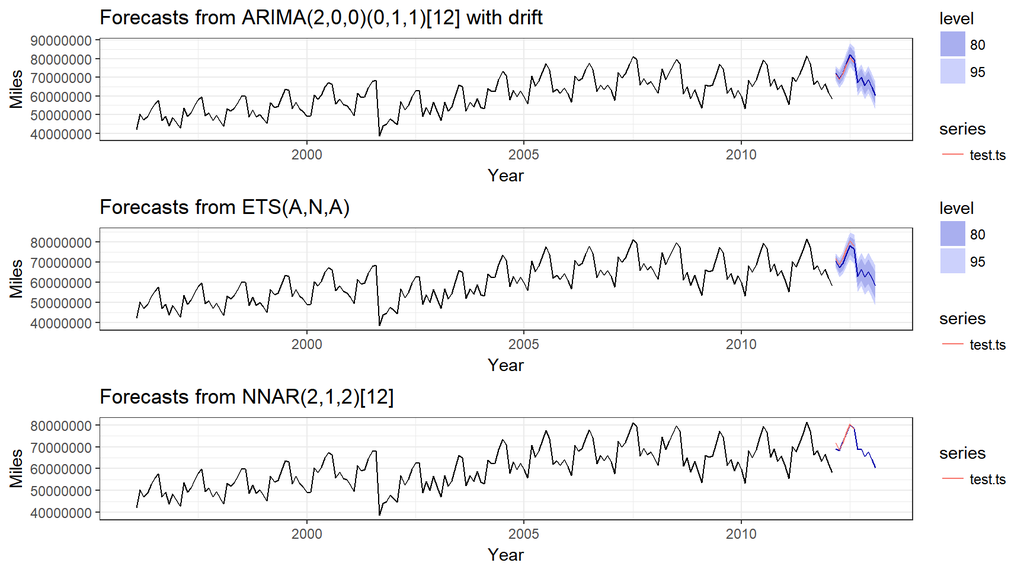

## 4. Conclusion

In conclusion, we would select the neural model because it performed better and also the forecast is pretty accurate.

RMarkdown code is available on my GitHub page (https://github.com/Singh-Gurjeet) in the Time Series and Forecasting repository.

## 5. Appendix I: R Code

```r
knitr::opts_chunk$set(echo = TRUE, warning = F, message = F)

library(tidyverse)
library(fpp)
options(scipen = 999)
#Import the data
US.air.traffic  <- read.csv("us-air-carrier-traffic-statistic.csv")
colnames(US.air.traffic) <- c("YearMonth", "Revenue_Miles")
autoplot(ts(US.air.traffic[,"Revenue_Miles"],
              frequency = 12)) +
  ggtitle(paste0("U.S. Air ",
                   "Carrier Traffic Statistics ",
                   "- Revenue Passenger Miles")) +
  xlab("Year")+
  ylab("Miles")+
  theme_bw()
# #Split the data into training set and test set
data.ts<-ts(US.air.traffic[,"Revenue_Miles"], frequency=12)
train.ts<-ts(US.air.traffic[1:193,"Revenue_Miles"],end=c(2012,2),frequency=12)
test.ts<-ts(US.air.traffic[194:199,"Revenue_Miles"],start=c(2012,3),frequency=12)
#Auto Arima
traffic.arima <- auto.arima(data.ts)
#ETS AUTO Model
traffic.ets <- ets(data.ts)
#Neural Network auto selection model
fit_nn <- nnetar(data.ts, lambda=0)

#Metrics
aa.model <- accuracy(traffic.arima)
est.model <- accuracy(traffic.ets)
nn.model <- accuracy(fit_nn)

rownames(aa.model) <- "ARIMA(2,0,0)(0,1,1)[12] with drift"
rownames(est.model) <- "ETS(A,N,A) "
rownames(nn.model) <- "NNAR(1,1,2)[12]"

knitr::kable(rbind(aa.model, est.model, nn.model),
             caption = "Metrics for each model using full data")

set.seed(123)
#Auto Arima using training dataset
traffic.arima.train <- auto.arima(train.ts)
fcast.arima.train <- forecast(traffic.arima.train, h=12)
acc.arima <- accuracy(fcast.arima.train, test.ts)
rownames(acc.arima) <- c("Auto Arima - Train","Auto Arima - Test")

#Auto ETS using training dataset
traffic.ets.train <- ets(train.ts)
fcast.ets.train <- forecast(traffic.ets.train, h=12)
acc.ets <- accuracy(fcast.ets.train, test.ts)
rownames(acc.ets) <- c("Auto ETS - Train","Auto ETS - Test")

#Auto ETS using training dataset
traffic.nn.train <- nnetar(train.ts)
fcast.nn.train <- forecast(traffic.nn.train, h=12)
acc.nn <- accuracy(fcast.nn.train, test.ts)
rownames(acc.nn) <- c("Auto Neural Network - Train","Auto Neural Network - Test")

knitr::kable(rbind(acc.arima[,1:7], acc.ets[,1:7], acc.nn[,1:7]),
             caption = "Metrics for each model")

AA_plot <- autoplot(fcast.arima.train) +
            autolayer(test.ts) +
            xlab("Year")+
            ylab("Miles")+
            theme_bw()

ETS_plot <- autoplot(fcast.ets.train) +
            autolayer(test.ts) +
            xlab("Year")+
            ylab("Miles")+
            theme_bw()

NN_plot <- autoplot(fcast.nn.train) +
            autolayer(test.ts) +
            xlab("Year")+
            ylab("Miles")+
            theme_bw()
gridExtra::grid.arrange(AA_plot,ETS_plot,NN_plot, nrow = 3)
```